# DDS Budweiser Analysis

Anishka Peter and Aaron Abromowitz

2023-07-01

## Introduction

Hello, my name is Anishka Peter and my partner is Aaron Abromowitz. We were given two datasets about beers and breweries and we are excited to present to you our findings. We first cleaned that data and addressed any missing values. Using that cleaned data, we found various insights such as the beers and breweries by state and style. We will include insights about AVB and IBU as well.

## Load Packages

```r
# packages
library(tidyverse)
```

```r
library(plotly)
library(ggpmisc) # stat_poly_eq
library(patchwork) # combining plots
library(e1071) # knn
library(caret) # knn
library(class) # knn
library(GGally) # ggpairs
library(dplyr)
```

## Load Datasets

We are loading in both data sets that we were given.

```r
breweries <- read.csv("https://raw.githubusercontent.com/anishkapeter/DDS_Budweiser_Project/main/Breweries.csv",header=TRUE)
beers <- read.csv("https://raw.githubusercontent.com/anishkapeter/DDS_Budweiser_Project/main/Beers.csv",header=TRUE)
```

## Question 1: Breweries by State

We are grouping all the breweries by state and then plotting a bar plot with the counts for the states.

```r
head(breweries)
```

```
##   Brew_ID                      Name          City State
## 1       1        NorthGate Brewing    Minneapolis    MN
## 2       2 Against the Grain Brewery    Louisville    KY
## 3       3  Jack's Abby Craft Lagers    Framingham    MA
## 4       4 Mike Hess Brewing Company     San Diego    CA
## 5       5   Fort Point Beer Company San Francisco    CA
## 6       6     COAST Brewing Company    Charleston    SC
```

```r
dim(breweries) # 558 4
```

```
## [1] 558   4
```

```r
breweries_by_state <-
  breweries %>%
  group_by(State) %>%
  summarize(count=n())

breweries_by_state %>% arrange(desc(count)) # Descending
```

```
## # A tibble: 51 × 2
##    State count
##    <chr> <int>
##  1 " CO"    47
##  2 " CA"    39
##  3 " MI"    32
##  4 " OR"    29
##  5 " TX"    28
##  6 " PA"    25
##  7 " MA"    23
##  8 " WA"    23
##  9 " IN"    22
## 10 " WI"    20
## # ℹ 41 more rows
```

```r
breweries_by_state %>% arrange(count) # Ascending
```

```
## # A tibble: 51 × 2
##    State count
##    <chr> <int>
##  1 " DC"     1
##  2 " ND"     1
##  3 " SD"     1
##  4 " WV"     1
##  5 " AR"     2
##  6 " DE"     2
##  7 " MS"     2
##  8 " NV"     2
##  9 " AL"     3
## 10 " KS"     3
## # ℹ 41 more rows
```

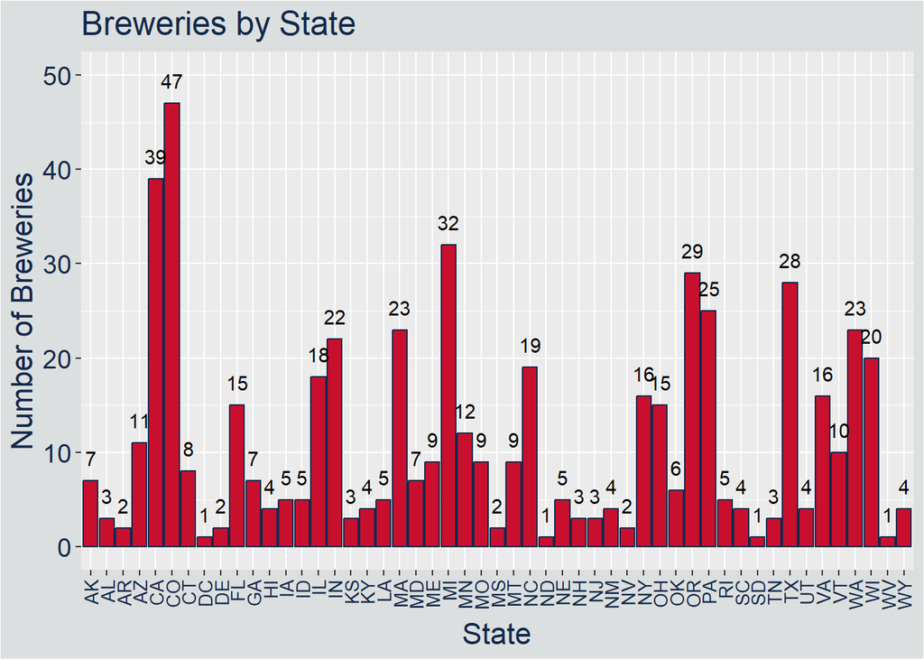

```r
breweries_by_state %>%
  ggplot(aes(x=State, y = count)) +
  geom_bar(stat = "Identity", color = "#13294b", fill = "#c8102e") +
  geom_text(aes(label = count), vjust = -1) +
  ggtitle('Breweries by State') +
  ylab("Number of Breweries")+
  ylim(0,50) +
  theme(plot.background = element_rect("#dbdfdf"),axis.text.x = element_text(angle = 90, vjust = 0.5, hjust=1, color = "#13294b",size = 10),axis.text.y = element_text(color = "#13294b",size = 14), axis.title.x = element_text(color = "#13294b",size = 16), axis.title.y =element_text(color = "#13294b",size = 16), plot.title  = element_text(color = "#13294b",size = 18))
```

## Question 2 Merge Data Together

### Merge Beers and Breweries

We merged the beers and breweries data set by the Brewery_id and Brew_ID and printed the first 6 and last 6 of the dataframe.

```r
beers_and_breweries <- merge(x=beers, y=breweries, by.x="Brewery_id", by.y="Brew_ID")
beers_and_breweries <- rename(beers_and_breweries,Brewery_Name="Name.y")
beers_and_breweries <- rename(beers_and_breweries,Beer_Name="Name.x")

# Save off original dataset
beers_and_breweries_original <- beers_and_breweries

head(beers_and_breweries,6)
```

```
##   Brewery_id     Beer_Name Beer_ID   ABV IBU
## 1          1  Get Together    2692 0.045  50
## 2          1 Maggie's Leap    2691 0.049  26
## 3          1    Wall's End    2690 0.048  19
## 4          1       Pumpion    2689 0.060  38
## 5          1    Stronghold    2688 0.060  25
## 6          1   Parapet ESB    2687 0.056  47
##                                 Style Ounces       Brewery_Name        City
## 1                        American IPA     16 NorthGate Brewing  Minneapolis
## 2                  Milk / Sweet Stout     16 NorthGate Brewing  Minneapolis
## 3                   English Brown Ale     16 NorthGate Brewing  Minneapolis
## 4                         Pumpkin Ale     16 NorthGate Brewing  Minneapolis
## 5                     American Porter     16 NorthGate Brewing  Minneapolis
## 6 Extra Special / Strong Bitter (ESB)     16 NorthGate Brewing  Minneapolis
##   State
## 1    MN
## 2    MN
## 3    MN
## 4    MN
## 5    MN
## 6    MN
```

```r
tail(beers_and_breweries,6)
```

```
##      Brewery_id                 Beer_Name Beer_ID   ABV IBU
## 2405        556             Pilsner Ukiah      98 0.055  NA
## 2406        557  Heinnieweisse Weissebier      52 0.049  NA
## 2407        557           Snapperhead IPA      51 0.068  NA
## 2408        557         Moo Thunder Stout      50 0.049  NA
## 2409        557         Porkslap Pale Ale      49 0.043  NA
## 2410        558 Urban Wilderness Pale Ale      30 0.049  NA
##                        Style Ounces                  Brewery_Name          City
## 2405         German Pilsener     12         Ukiah Brewing Company         Ukiah
## 2406              Hefeweizen     12       Butternuts Beer and Ale Garrattsville
## 2407            American IPA     12       Butternuts Beer and Ale Garrattsville
## 2408      Milk / Sweet Stout     12       Butternuts Beer and Ale Garrattsville
## 2409 American Pale Ale (APA)     12       Butternuts Beer and Ale Garrattsville
## 2410        English Pale Ale     12 Sleeping Lady Brewing Company     Anchorage
##      State
## 2405    CA
## 2406    NY
## 2407    NY
## 2408    NY
## 2409    NY
## 2410    AK
```

### Remove non-beer styles

Some of the beers in the data set, are not considered real beers so we removed them.

```r
beers_and_breweries <- beers_and_breweries[beers_and_breweries$Style != "American Malt Liquor", ] # not a beer
beers_and_breweries <- beers_and_breweries[beers_and_breweries$Style != "Braggot", ] # not a beer
beers_and_breweries <- beers_and_breweries[beers_and_breweries$Style != "Cider", ] # not a beer
beers_and_breweries <- beers_and_breweries[beers_and_breweries$Style != "Mead", ] # not a beer
beers_and_breweries <- beers_and_breweries[beers_and_breweries$Style != "Low Alcohol Beer", ] # not a beer
beers_and_breweries <- beers_and_breweries[beers_and_breweries$Style != "Radler", ] # not a beer
beers_and_breweries <- beers_and_breweries[beers_and_breweries$Style != "Shandy", ] # not a beer
```

### Counts for non-beers styles

```r
malt_liquor <- beers_and_breweries[beers_and_breweries$Style == "American Malt Liquor", ] # not a beer
braggot <- beers_and_breweries[beers_and_breweries$Style == "Braggot", ] # not a beer
cider <- beers_and_breweries[beers_and_breweries$Style == "Cider", ] # not a beer
mead <- beers_and_breweries[beers_and_breweries$Style == "Mead", ] # not a beer
low_alcohol <- beers_and_breweries[beers_and_breweries$Style == "Low Alcohol Beer", ] # not a beer
radler <- beers_and_breweries[beers_and_breweries$Style == "Radler", ] # not a beer
shandy <- beers_and_breweries[beers_and_breweries$Style == "Shandy", ] # not a beer
non_beers <- rbind(malt_liquor,braggot,cider,mead,low_alcohol,radler,shandy)
non_beer_counts <- non_beers %>%
  group_by(Style) %>%
  summarise(Count=n())
```

## Question 3: Address Missing Values

We plotted the percentage of values that are missing for the 3 variables that have missing values.

```r
dim(beers_and_breweries %>% filter(is.na(ABV) & !is.na(IBU)))[1] # No results, ABV is missing only if IBU is missing as well
```

```
## [1] 0
```

```r
dim(beers_and_breweries %>% filter(Style==''))[1] # 5 results, 2 with ABV and IBU, 3 with  neither = 0.2%
```

```
## [1] 5
```

```r
dim(beers_and_breweries %>% filter(is.na(ABV) & is.na(IBU)))[1] # 62 results / 2359 = 2.6%
```

```
## [1] 62
```

```r
dim(beers_and_breweries %>% filter(!is.na(ABV) & is.na(IBU)))[1] # 895 results / 2359 = 37.9%
```

```
## [1] 895
```

```r
# Plot a single bar with missing counts and percentages

Count <- c(5, 62, 895)
Category <- c("Style", "ABV", "IBU")
count_df <- data.frame(Count, Category)
count_df$Percent <- round(count_df$Count / 2359 *100,1)
count_df$Category <- factor(count_df$Category,level=c("IBU", "ABV", "Style" ))
summary(count_df)
```

```
##      Count        Category    Percent
##  Min.   :  5.0   IBU  :1   Min.   : 0.20
##  1st Qu.: 33.5   ABV  :1   1st Qu.: 1.40
##  Median : 62.0   Style:1   Median : 2.60
##  Mean   :320.7             Mean   :13.57
##  3rd Qu.:478.5             3rd Qu.:20.25
##  Max.   :895.0             Max.   :37.90
```

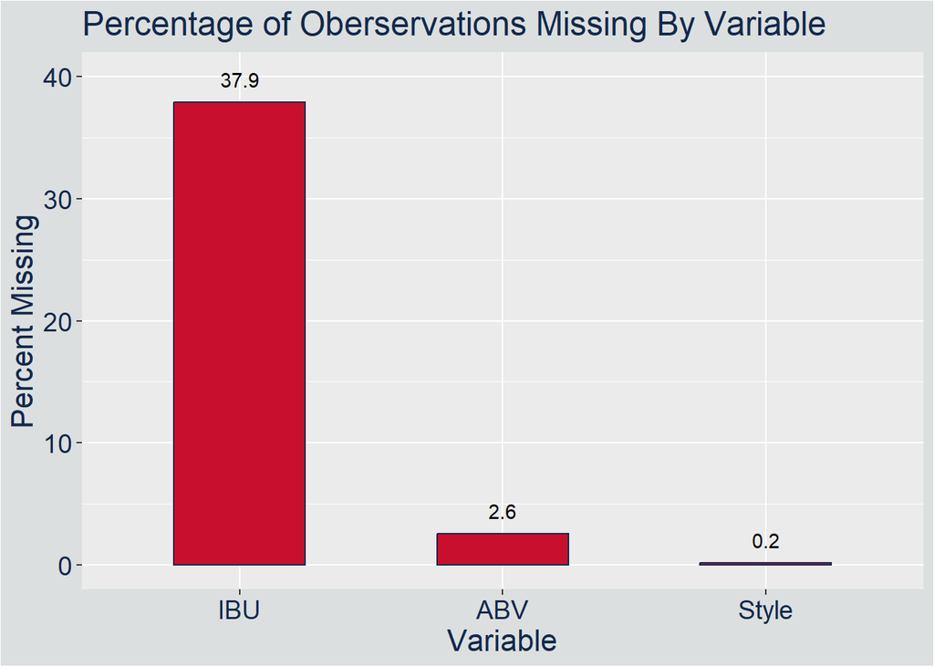

```r
ggplot(count_df,aes(x=Category, y=Percent)) +
  geom_bar(stat="identity",width=.5,position = "Dodge",fill = "#c8102e",color = "#13294b" ) +
  xlab("Variable")  +
  ylab("Percent Missing") +
  ggtitle("Percentage of Oberservations Missing By Variable")+
  geom_text(aes(label = Percent), vjust = -1) +
  ylim(0,40) +
  theme(plot.background = element_rect("#dbdfdf"),
        axis.text.x = element_text(color = "#13294b",size = 14),
        axis.text.y = element_text(color = "#13294b",size = 14),
        axis.title.x = element_text(color = "#13294b",size = 16),
        axis.title.y =element_text(color = "#13294b",size = 16),
        plot.title  = element_text(color = "#13294b",size = 18))
```

### Add in the Styles

We are imputing style for the 5 missing styles, or removing the entries entirely.

```r
no_missing_style <- beers_and_breweries %>%
  filter(Style != '' ) # 2405
missing_style <- beers_and_breweries %>%
  filter(Style == '' ) # 5
missing_style <- missing_style[missing_style$Beer_ID != 2210,] # The beer style changes
missing_style$Style[missing_style$Beer_ID == 2527] <- "Märzen / Oktoberfest"
missing_style$Style[missing_style$Beer_ID == 1635] <- "Scottish Ale"
missing_style <- missing_style[missing_style$Beer_ID != 1796,] # It looks like The CROWLER™ is a container, not a beer
missing_style <- missing_style[missing_style$Beer_ID != 1790,] # It looks like CAN'D AID Foundation is a charity, not a beer
beers_and_breweries <- rbind(no_missing_style,missing_style) # 2356
# Merged data frame with filled in Styles but still missing ABV and IBU
head(beers_and_breweries)
```

```
##   Brewery_id     Beer_Name Beer_ID   ABV IBU
## 1          1  Get Together    2692 0.045  50
## 2          1 Maggie's Leap    2691 0.049  26
## 3          1    Wall's End    2690 0.048  19
## 4          1       Pumpion    2689 0.060  38
## 5          1    Stronghold    2688 0.060  25
## 6          1   Parapet ESB    2687 0.056  47
##                                 Style Ounces       Brewery_Name        City
## 1                        American IPA     16 NorthGate Brewing  Minneapolis
## 2                  Milk / Sweet Stout     16 NorthGate Brewing  Minneapolis
## 3                   English Brown Ale     16 NorthGate Brewing  Minneapolis
## 4                         Pumpkin Ale     16 NorthGate Brewing  Minneapolis
## 5                     American Porter     16 NorthGate Brewing  Minneapolis
## 6 Extra Special / Strong Bitter (ESB)     16 NorthGate Brewing  Minneapolis
##   State
## 1    MN
## 2    MN
## 3    MN
## 4    MN
## 5    MN
## 6    MN
```

```r
tail(beers_and_breweries)
```

```
##      Brewery_id                      Beer_Name Beer_ID   ABV IBU
## 2351        557                Snapperhead IPA      51 0.068  NA
## 2352        557              Moo Thunder Stout      50 0.049  NA
## 2353        557              Porkslap Pale Ale      49 0.043  NA
## 2354        558      Urban Wilderness Pale Ale      30 0.049  NA
## 2355         67                  OktoberFiesta    2527 0.053  27
## 3100        161 Kilt Lifter Scottish-Style Ale    1635 0.060  21
##                        Style Ounces                  Brewery_Name          City
## 2351            American IPA     12       Butternuts Beer and Ale Garrattsville
## 2352      Milk / Sweet Stout     12       Butternuts Beer and Ale Garrattsville
## 2353 American Pale Ale (APA)     12       Butternuts Beer and Ale Garrattsville
## 2354        English Pale Ale     12 Sleeping Lady Brewing Company     Anchorage
## 2355    Märzen / Oktoberfest     12      Freetail Brewing Company   San Antonio
## 3100            Scottish Ale     12    Four Peaks Brewing Company         Tempe
##      State
## 2351    NY
## 2352    NY
## 2353    NY
## 2354    AK
## 2355    TX
## 3100    AZ
```

### Missing ABV

We plotted the number of Missing ABV vs number of non-missing abv’s and then looked to see if there is any pattern in the way ABV is missing, by state, by styles, or by breweries. Then we looked at if ABV values are related to the style

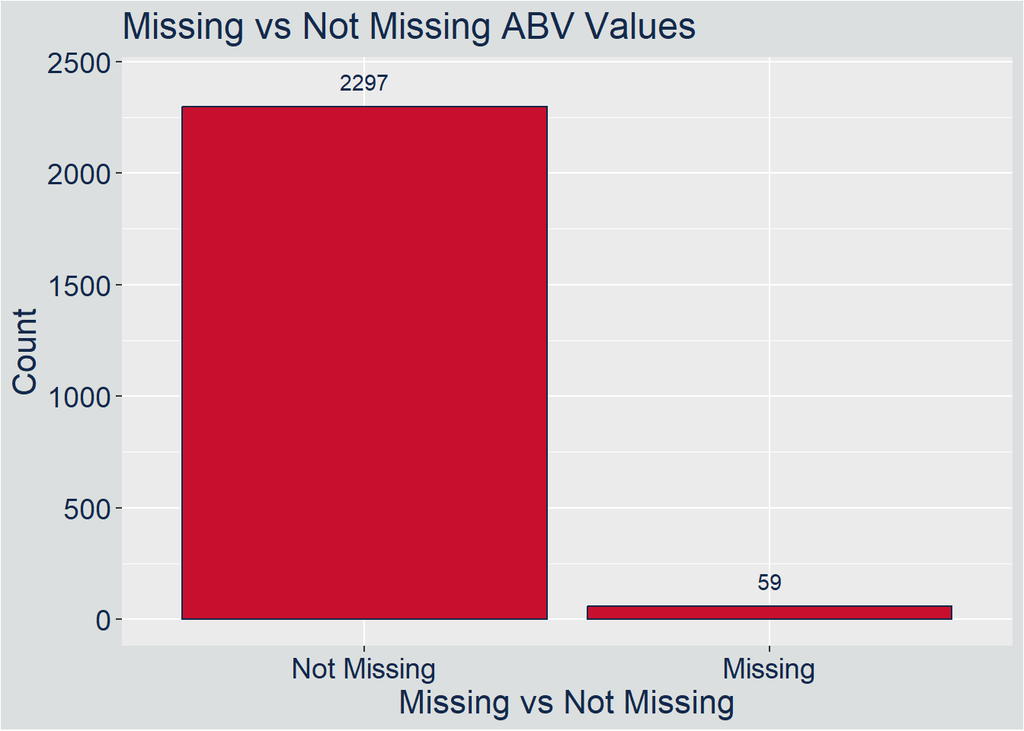

```r
## Count of Missing ABV vs Non-Missing ABV
missing_non_missing_abv = data.frame(beers_and_breweries,is.na(beers_and_breweries$ABV))
missing_non_missing_abv %>%
  group_by(is.na.beers_and_breweries.ABV.) %>%
  summarise(count = n()) %>%
  ggplot(aes(x = as.character(is.na.beers_and_breweries.ABV.), y = count)) +
  geom_bar(stat = "identity", color = "#13294b", fill = "#c8102e") +
  scale_x_discrete(labels=c("Not Missing", "Missing")) +
  xlab("Missing vs Not Missing") +
  ylab("Count")+
  ggtitle("Missing vs Not Missing ABV Values") +
  ylim(0,2400)+
  geom_text(aes(label = count),vjust = -1,color = "#13294b") +
  theme(plot.background = element_rect("#dbdfdf"),
        axis.text.x = element_text(color = "#13294b",size = 14),
        axis.text.y = element_text(color = "#13294b",size = 14),
        axis.title.x = element_text(color = "#13294b",size = 16),
        axis.title.y =element_text(color = "#13294b",size = 16),
        plot.title  = element_text(color = "#13294b",size = 18))
```

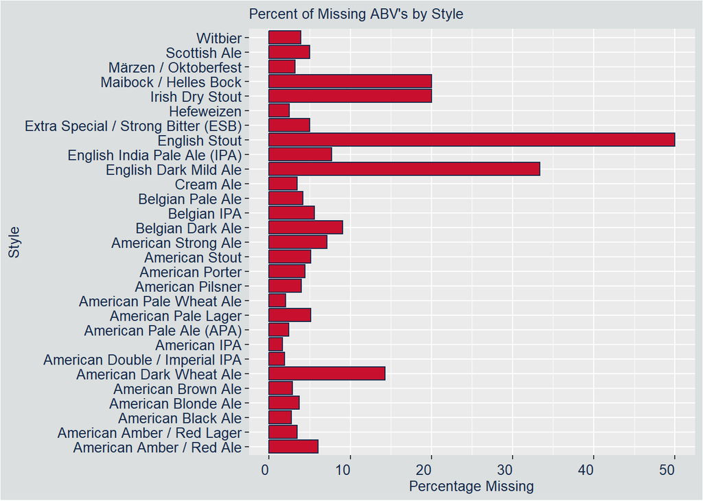

```r
# Plot the percentage of ABVs missing by style
missing_abv <- beers_and_breweries %>%
  filter(is.na(ABV))
missing_abv_styles <- missing_abv %>%
  group_by(Style) %>%
  summarise(count=n())
total_styles <- beers_and_breweries %>%
  group_by(Style) %>%
  summarise(count=n())
style_missing_abv_comparison <- merge(total_styles,missing_abv_styles,by="Style")
style_missing_abv_comparison <- style_missing_abv_comparison %>% # No styles are missing all, so can extrapolate abv
  mutate(per_missing = 100*count.y/count.x)

ggplot(style_missing_abv_comparison,aes(x = Style,y = per_missing)) +
  geom_bar(stat = "Identity", fill = "#c8102e", color = "#13294b" ) +
  coord_flip() +
  ggtitle("Percent of Missing ABV's by Style") +
  labs(y = "Percentage Missing") +
  theme(plot.background = element_rect("#dbdfdf"),axis.text.x = element_text(angle = 0, vjust = 0.5, hjust=1, color = "#13294b",size = 10),axis.text.y = element_text(color = "#13294b",size = 10), axis.title.x = element_text(color = "#13294b",size = 10), axis.title.y =element_text(color = "#13294b",size = 10), plot.title  = element_text(color = "#13294b",size = 10))
```

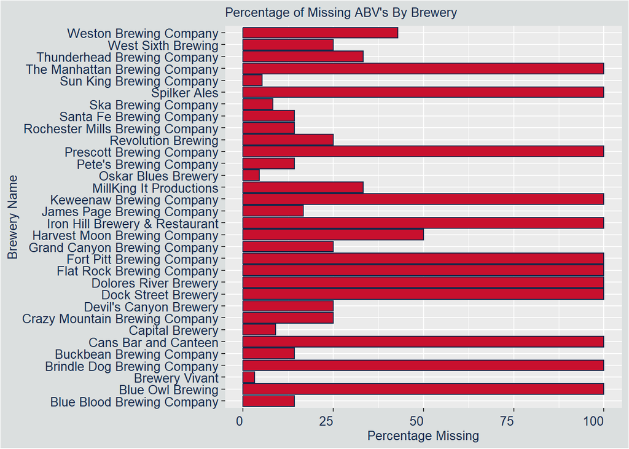

```r
# Plot missing AVB by Breweries
missing_abv_breweries <- missing_abv %>%
  group_by(Brewery_Name) %>%
  summarise(count=n())
total_breweries <- beers_and_breweries %>%
  group_by(Brewery_Name) %>%
  summarise(count=n())
brewery_missing_abv_comparison <- merge(total_breweries,missing_abv_breweries,by="Brewery_Name")
brewery_missing_abv_comparison <- brewery_missing_abv_comparison %>% # Some breweries didn't report abv
  mutate(per_missing = 100*count.y/count.x)

ggplot(brewery_missing_abv_comparison,aes(x = Brewery_Name,y = per_missing)) +
  geom_bar(stat = "Identity", fill = "#c8102e", color = "#13294b" ) +
  coord_flip() +
  ggtitle("Percentage of Missing ABV's By Brewery") +
  labs(x = "Brewery Name", y = "Percentage Missing") +
  theme(plot.background = element_rect("#dbdfdf"),axis.text.x = element_text(angle = 0, vjust = 0.5, hjust=1, color = "#13294b",size = 10),axis.text.y = element_text(color = "#13294b",size = 10), axis.title.x = element_text(color = "#13294b",size = 10), axis.title.y =element_text(color = "#13294b",size = 10), plot.title  = element_text(color = "#13294b",size = 10))
```

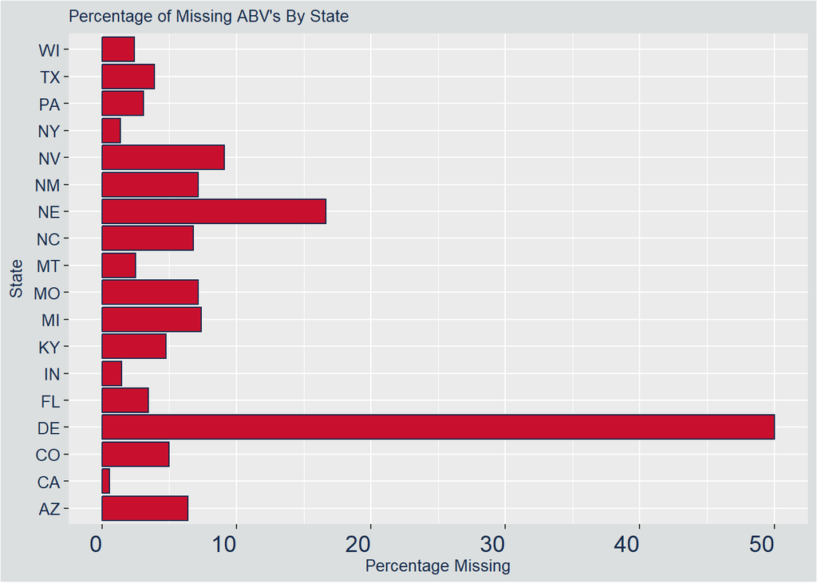

```r
# Plot missing AVB by State
missing_abv_states <- missing_abv %>%
  group_by(State) %>%
  summarise(count=n())
total_states <- beers_and_breweries %>%
  group_by(State) %>%
  summarise(count=n())
state_missing_abv_comparison <- merge(total_states,missing_abv_states,by="State")
state_missing_abv_comparison <- state_missing_abv_comparison %>%
  mutate(per_missing = 100*count.y/count.x)

ggplot(state_missing_abv_comparison,aes(x = State,y = per_missing)) +
  geom_bar(stat = "Identity", fill = "#c8102e", color = "#13294b" ) +
  coord_flip() +
  ggtitle("Percentage of Missing ABV's By State") +
    labs(x = "State", y = "Percentage Missing") +
  theme(plot.background = element_rect("#dbdfdf"),axis.text.x = element_text(angle = 0, vjust = 0.5, hjust=1, color = "#13294b",size = 14),axis.text.y = element_text(color = "#13294b",size = 10), axis.title.x = element_text(color = "#13294b",size = 10), axis.title.y =element_text(color = "#13294b",size = 10), plot.title  = element_text(color = "#13294b",size = 10))
```

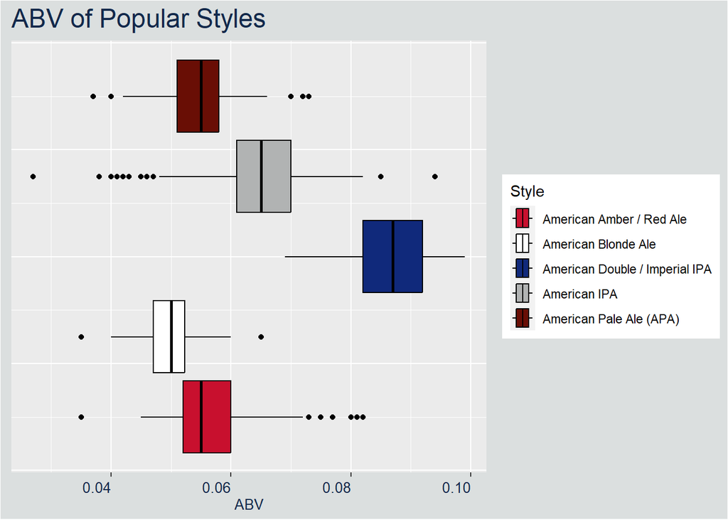

```r
# Since ABV is highly based on style, create boxplots of the Popular Styles colored by ABV.
# Do this for the most popular styles to reduce the number of boxplots.
style_counts <- beers_and_breweries %>%
  group_by(Style) %>%
  summarize(Count = n())
popular_styles <- style_counts$Style[style_counts$Count > 100]
colors = c("#c8102e","#ffffff","#10297b","#b1b3b3","#690E05")
beers_and_breweries_original %>% filter(Style %in% popular_styles) %>%
  ggplot(aes(x=ABV,fill=Style)) +
  geom_boxplot(color="black") + ggtitle('ABV of Popular Styles') +
  theme(plot.background = element_rect("#dbdfdf"),
        axis.text.x = element_text(angle = 0, vjust = 0.5, hjust=1, color = "#13294b",size = 10),
        axis.text.y = element_blank(),
        axis.title.x = element_text(color = "#13294b",size = 10),
        axis.title.y =element_text(color = "#13294b",size = 16),
        plot.title  = element_text(color = "#13294b",size = 18),
        axis.ticks.y= element_blank()) +
        scale_fill_manual(values = colors)
```

### Missing IBU

We are investigating to see if the missing IBUs have any pattern by State, Brewery, or Style. Then we looked at if IBU values are related to the style of beer. It looks like certain Breweries have all their beers missing IBUs, where other breweries have none of their beers missing IBUs.

```r
# Missing IBU by Style
missing_ibu <- beers_and_breweries %>%
  filter(is.na(IBU))
missing_ibu_styles <- missing_ibu %>%
  group_by(Style) %>%
  summarise(count=n())
style_missing_ibu_comparison <- merge(total_styles,missing_ibu_styles,by="Style")
style_missing_ibu_comparison <- style_missing_ibu_comparison %>%
  mutate(per_missing = 100*count.y/count.x)

# Missing IBU by Brewery
missing_ibu_breweries <- missing_ibu %>%
  group_by(Brewery_Name) %>%
  summarise(count=n())
brewery_missing_ibu_comparison <- merge(total_breweries,missing_ibu_breweries,by="Brewery_Name")
brewery_missing_ibu_comparison <- brewery_missing_ibu_comparison %>% # Lots of breweries are missing IBUs
  mutate(per_missing = 100*count.y/count.x)

# Missing IBU by State
missing_ibu_states <- missing_ibu %>%
  group_by(State) %>%
  summarise(count=n())
total_states <- beers_and_breweries %>%
  group_by(State) %>%
  summarise(count=n())
state_missing_ibu_comparison <- merge(total_states,missing_ibu_states,by="State")
state_missing_ibu_comparison <- state_missing_ibu_comparison %>% # Lots of breweries are missing IBUs
  mutate(per_missing = 100*count.y/count.x)
head(state_missing_ibu_comparison)
```

```
##   State count.x count.y per_missing
## 1    AK      25       8    32.00000
## 2    AL      10       1    10.00000
## 3    AR       5       4    80.00000
## 4    AZ      47      23    48.93617
## 5    CA     182      47    25.82418
## 6    CO     260     114    43.84615
```

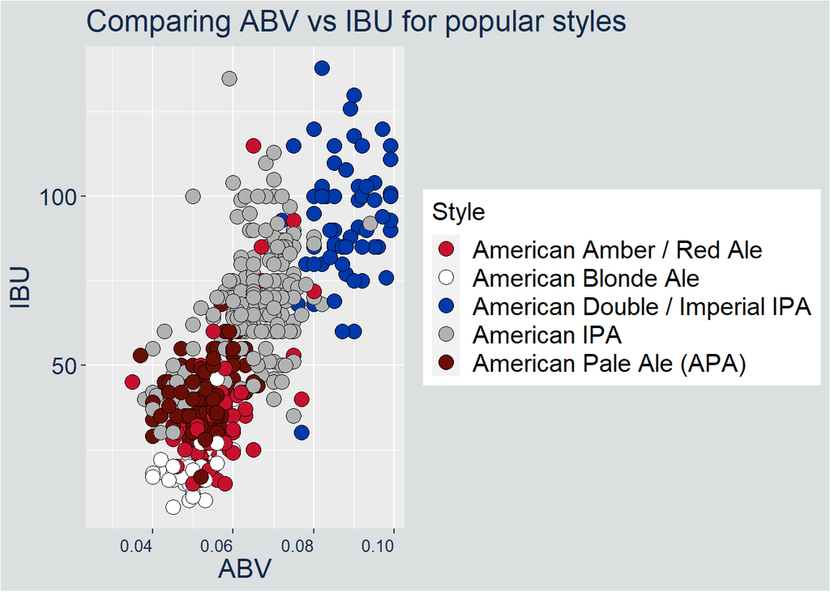

```r
# CONCLUSION: It does seem to be pretty random which states and styles have missing IBUs, but some breweries are missing all and some are missing none.

# Filtering on the highest counts of styles, then plot to see if they have clear separation for ABV and IBU
style_counts <- beers_and_breweries %>%
  group_by(Style) %>%
  summarize(Count = n())
popular_styles <- style_counts$Style[style_counts$Count > 100]
medians_by_popular_style <- beers_and_breweries %>%
  filter(Style %in% popular_styles) %>%
  group_by(Style) %>%
  summarize(median_abv=median(ABV),median_ibu=median(IBU))

colors = c("#c8102e","#ffffff","#0039AA","#b1b3b3","#690E05")

beers_and_breweries %>% filter(Style %in% popular_styles) %>%
  ggplot(aes(x=ABV,y=IBU,color=Style)) +
  geom_point(aes(fill=Style),color = "BLACK", pch = 21,size = 4) + ggtitle('Comparing ABV vs IBU for popular styles') +
  theme(plot.background = element_rect("#dbdfdf"),
        axis.text.x = element_text(angle = 0, vjust = 0.5, hjust=1, color = "#13294b",size = 10),
        axis.text.y = element_text(color = "#13294b",size = 14),
        axis.title.x = element_text(color = "#13294b",size = 16),
        axis.title.y =element_text(color = "#13294b",size = 16),
        plot.title  = element_text(color = "#13294b",size = 18),
        legend.text = element_text(size=15),
        legend.title = element_text(size=15))+
        scale_fill_manual(values = colors)
```

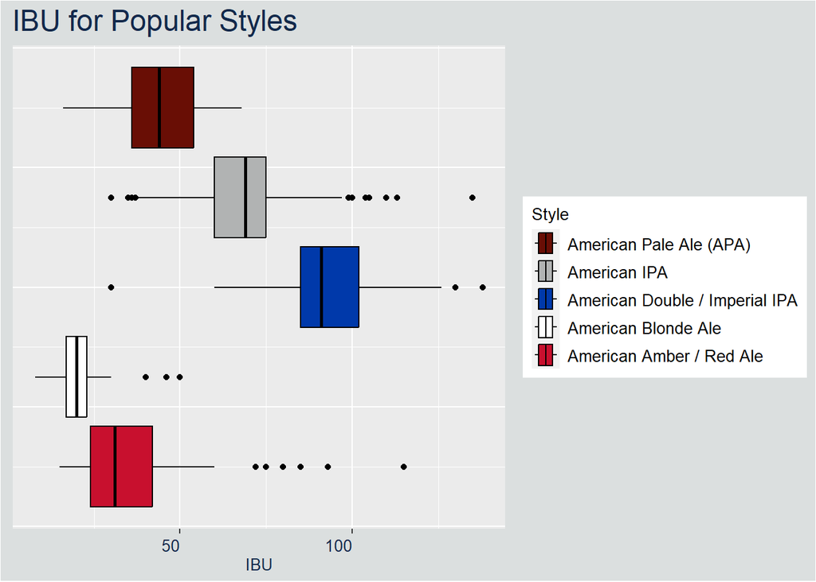

```r
# Popular Styles colored by IBU, Boxplot
beers_and_breweries %>% filter(Style %in% popular_styles) %>%
  ggplot(aes(x=IBU,fill=Style)) +
  geom_boxplot(color="black") + ggtitle('IBU for Popular Styles') +
  theme(plot.background = element_rect("#dbdfdf"),
        axis.text.x = element_text(angle = 0, vjust = 0.5, hjust=1, color = "#13294b",size = 10),
        axis.text.y = element_blank(),
        axis.title.x = element_text(color = "#13294b",size = 10),
        axis.title.y =element_text(color = "#13294b",size = 16),
        plot.title  = element_text(color = "#13294b",size = 18),
        axis.ticks.y = element_blank(),
        legend.text = element_text(size=10),
        legend.title = element_text(size=10)) +
        scale_fill_manual(values = colors) +
  guides(fill = guide_legend(reverse=TRUE))
```

```r
#CONCLUSION: The IBU's for each beer style seem to be clusered together, so IBU is based on the Style
```

### Impute Missing ABV and IBU Values

#### Impute Missing Values for ABV

```r
# Calculate Median ABV by style
missing_abv <- beers_and_breweries %>%
  filter(is.na(ABV)) # 60
non_missing_abv <- beers_and_breweries %>%
  filter(!is.na(ABV)) # 2348
med_abv_per_style <- non_missing_abv %>% # Looks like low alcohol beer even has a small ABV
  group_by(Style) %>%
  summarise(med=round(median(ABV),3))

# Impute Missing ABV with Median ABV for Style
missing_abv <- merge(missing_abv,med_abv_per_style,by="Style")
missing_abv$ABV <- missing_abv$med
head(missing_abv)
```

```
##                      Style Brewery_id                      Beer_Name Beer_ID
## 1 American Amber / Red Ale         64                 Boohai Red Ale     940
## 2 American Amber / Red Ale        549               Liquid Amber Ale      64
## 3 American Amber / Red Ale         64 WinterWonderGrass Festival Ale    1163
## 4 American Amber / Red Ale        489  Dock Street Amber Beer (1992)     944
## 5 American Amber / Red Ale         78                     Van Dayum!    2488
## 6 American Amber / Red Ale        152                  Fort Pitt Ale    2322
##     ABV IBU Ounces                   Brewery_Name         City State   med
## 1 0.055  NA     12 Crazy Mountain Brewing Company      Edwards    CO 0.055
## 2 0.055  NA     12       Prescott Brewing Company     Prescott    AZ 0.055
## 3 0.055  NA     12 Crazy Mountain Brewing Company      Edwards    CO 0.055
## 4 0.055  NA     12            Dock Street Brewery Philadelphia    PA 0.055
## 5 0.055  NA     12               Blue Owl Brewing       Austin    TX 0.055
## 6 0.055  NA     12      Fort Pitt Brewing Company      Latrobe    PA 0.055
```

```r
missing_abv$med <- NULL
beers_and_breweries <- rbind(missing_abv,non_missing_abv) # 2356
head(beers_and_breweries)
```

```
##                      Style Brewery_id                      Beer_Name Beer_ID
## 1 American Amber / Red Ale         64                 Boohai Red Ale     940
## 2 American Amber / Red Ale        549               Liquid Amber Ale      64
## 3 American Amber / Red Ale         64 WinterWonderGrass Festival Ale    1163
## 4 American Amber / Red Ale        489  Dock Street Amber Beer (1992)     944
## 5 American Amber / Red Ale         78                     Van Dayum!    2488
## 6 American Amber / Red Ale        152                  Fort Pitt Ale    2322
##     ABV IBU Ounces                   Brewery_Name         City State
## 1 0.055  NA     12 Crazy Mountain Brewing Company      Edwards    CO
## 2 0.055  NA     12       Prescott Brewing Company     Prescott    AZ
## 3 0.055  NA     12 Crazy Mountain Brewing Company      Edwards    CO
## 4 0.055  NA     12            Dock Street Brewery Philadelphia    PA
## 5 0.055  NA     12               Blue Owl Brewing       Austin    TX
## 6 0.055  NA     12      Fort Pitt Brewing Company      Latrobe    PA
```

#### Impute Missing IBU

IBUs are MAR when we checked by state, brewery and style and we observed that each style has a small range of IBU so we are imputing the missing IBU’s with the median IBU value. Some IBUs had all their values missing, so we looked those up in a Beer Style Guide.

```r
# Since some styles are missing all of their IBUs, we'll need to separate those out and look up those values in a Beer Style Guide
missing_ibu <- beers_and_breweries %>%
  filter(is.na(IBU)) # 1003
non_missing_ibu <- beers_and_breweries %>%
  filter(!is.na(IBU)) # 1405, wow not much more than half, mean IBU is 43
missing_ibu_styles <- missing_ibu %>%
  group_by(Style) %>%
  summarise(count=n())
total_styles <- beers_and_breweries %>%
  group_by(Style) %>%
  summarise(count=n())
style_missing_ibu_comparison <- merge(total_styles,missing_ibu_styles,by="Style")
style_missing_ibu_comparison <- style_missing_ibu_comparison %>%
  mutate(per_missing = 100*count.y/count.x)
styles_no_ibus <- style_missing_ibu_comparison$Style[style_missing_ibu_comparison$per_missing == 100]
missing_ibu_all_styles <- missing_ibu[missing_ibu$Style %in% styles_no_ibus,]

# Adding in IBUs for styles with no IBU values
missing_ibu_all_styles$IBU[missing_ibu_all_styles$Style == "Flanders Red Ale"] <- 20
missing_ibu_all_styles$IBU[missing_ibu_all_styles$Style == "Kristalweizen"] <- 13
missing_ibu_all_styles$IBU[missing_ibu_all_styles$Style == "Rauchbier"] <- 25


styles_with_ibus <- style_missing_ibu_comparison$Style[style_missing_ibu_comparison$per_missing != 100]

to_predict_ibus <- missing_ibu[missing_ibu$Style %in% styles_with_ibus,]

med_ibu_per_style <- non_missing_ibu %>% # Looks like low alcohol beer even has a small ABV
  group_by(Style) %>%
  summarise(med=round(median(IBU),0))
to_predict_ibus <- merge(to_predict_ibus,med_ibu_per_style,by="Style")
to_predict_ibus$IBU <- to_predict_ibus$med
to_predict_ibus$med <- NULL
beers_and_breweries <- rbind(non_missing_ibu,missing_ibu_all_styles,to_predict_ibus) # 2356
```

## Question 4: Median alcohol content and international bitterness unit for each state

We grouped the IBU and ABV by state and computed the medians. Then plotted the median ABV by state and median IBU by state

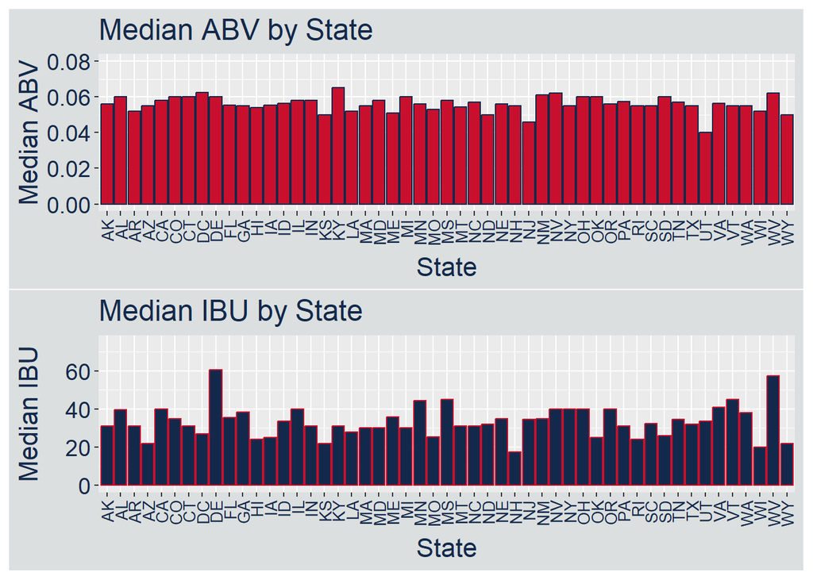

```r
medians_by_state <- beers_and_breweries %>%
  group_by(State) %>%
  summarise(median_abv=median(ABV),median_ibu=median(IBU))
mean_abv = mean(medians_by_state$median_abv)
mean_ibu = mean(medians_by_state$median_ibu)
median_abv_by_state <- beers_and_breweries %>%
  group_by(State) %>%
  summarise(Median=median(ABV))

plot1 <- ggplot(medians_by_state,aes(x = State, y = median_abv)) +
  geom_bar(stat = "Identity", color = "#13294b", fill = "#c8102e") +
  labs(x = "State", y = "Median ABV", title = "Median ABV by State") +
  ylim(0,0.08) +
  theme(plot.background = element_rect("#dbdfdf"),axis.text.x = element_text(angle = 90, vjust = 0.5, hjust=1, color = "#13294b",size = 10),axis.text.y = element_text(color = "#13294b",size = 14), axis.title.x = element_text(color = "#13294b",size = 16), axis.title.y =element_text(color = "#13294b",size = 16), plot.title  = element_text(color = "#13294b",size = 18))
plot2 <- ggplot(medians_by_state,aes(x = State, y = median_ibu)) +
  geom_bar(stat= "Identity", fill = "#13294b", color = "#c8102e") +
  labs(x = "State", y = "Median IBU", title = "Median IBU by State") +
  ylim(0,75) +
  theme(plot.background = element_rect("#dbdfdf"),axis.text.x = element_text(angle = 90, vjust = 0.5, hjust=1, color = "#13294b",size = 10),axis.text.y = element_text(color = "#13294b",size = 14), axis.title.x = element_text(color = "#13294b",size = 16), axis.title.y =element_text(color = "#13294b",size = 16), plot.title  = element_text(color = "#13294b",size = 18))
combined_plot <- plot1 / plot2 + plot_layout(ncol = 1)
print(combined_plot)
```

### Question 4 Answer

The median ABV for states is all around the same value with minimal variation between states except for Utah which is much lower than all the other states. The median IBU’s by state has much more variability depending on the state

## Question 5: Max ABV and Max IBU

We found the max ABV and IBU value. Then we plotted on a bar graph the states with the 10 highest IBU scores and the 10 highest ABV value.

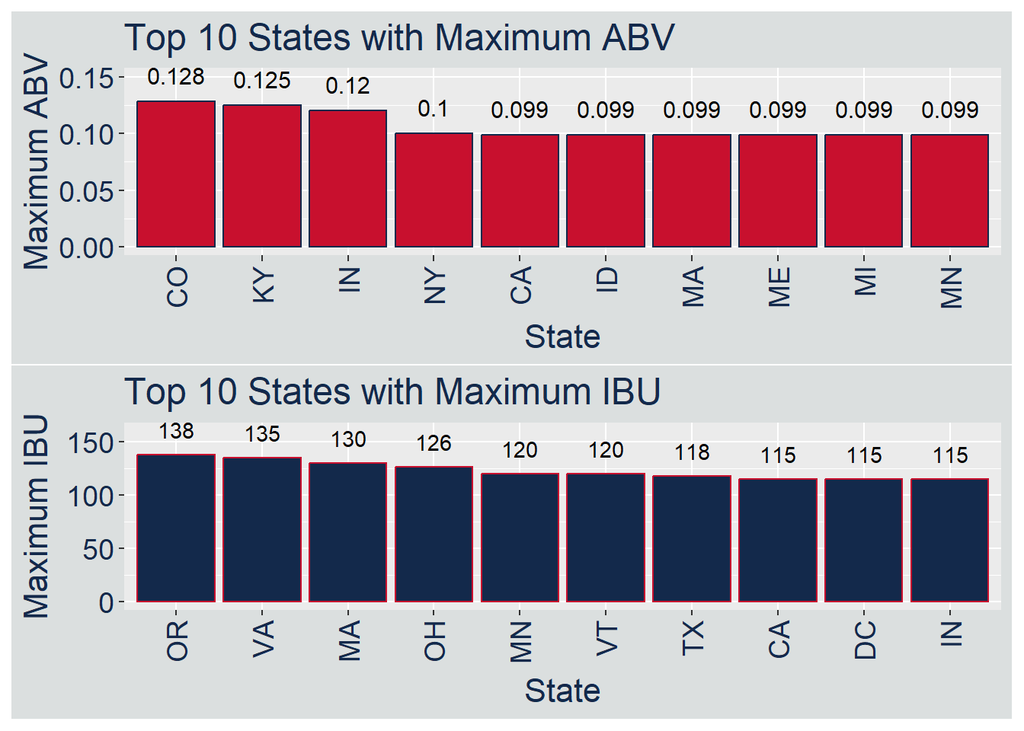

```r
max_abv_state <- beers_and_breweries$State[beers_and_breweries$ABV == max(beers_and_breweries$ABV)]
max_ibu_state <- beers_and_breweries$State[beers_and_breweries$IBU == max(beers_and_breweries$IBU)]


max_ibu_by_state <-beers_and_breweries %>%
  group_by(State)%>%
  summarise(maxibu = max(IBU))%>%
  arrange(desc(maxibu))

max_abv_by_state <-beers_and_breweries %>%
  group_by(State)%>%
  summarise(maxabv = max(ABV)) %>%
  arrange(desc(maxabv))

max_abv_by_state$State = factor(max_abv_by_state$State)
max_abv_by_state$State <- factor(max_abv_by_state$State,levels=names(sort(table(max_abv_by_state$State), decreasing=TRUE)))


plot1 <- head(max_abv_by_state, n = 10) %>%
  ggplot(aes(x = reorder(State , -maxabv), y = maxabv)) +
  geom_bar(stat = "Identity", color = "#13294b", fill = "#c8102e") +
  labs(x = "State", y = "Maximum ABV", title = "Top 10 States with Maximum ABV") +
  ylim(0,.15) +
  geom_text(aes(label = maxabv),vjust = -1,size = 4) +
  theme(plot.background = element_rect("#dbdfdf"),axis.text.x = element_text(angle = 90, vjust = 0.5, hjust=1, color = "#13294b",size = 14),axis.text.y = element_text(color = "#13294b",size = 14), axis.title.x = element_text(color = "#13294b",size = 16), axis.title.y =element_text(color = "#13294b",size = 16), plot.title  = element_text(color = "#13294b",size = 18))


plot2 <- head(max_ibu_by_state, n = 10) %>%
  ggplot(aes(x = reorder(State, -maxibu), y = maxibu)) +
  geom_bar(stat= "Identity", fill = "#13294b", color = "#c8102e") +
  labs(x = "State", y = "Maximum IBU", title = "Top 10 States with Maximum IBU") +
  ylim(0,160) +
  geom_text(aes(label = maxibu),vjust = -1) +
  theme(plot.background = element_rect("#dbdfdf"),axis.text.x = element_text(angle = 90, vjust = 0.5, hjust=1, color = "#13294b",size = 14),axis.text.y = element_text(color = "#13294b",size = 14), axis.title.x = element_text(color = "#13294b",size = 16), axis.title.y =element_text(color = "#13294b",size = 16), plot.title  = element_text(color = "#13294b",size = 18))

combined_plot <- plot1 / plot2 + plot_layout(ncol = 1)
print(combined_plot)
```

### Question 5 Answer

The maximum ABV is 0.128 from Colorado, Lee Hill Series Vol. 5 - Belgian Style Quadrupel Ale. The maximum IBU is in Orgeon with a score of 138, Bitter Bitch Imperial IPA.

## Question 6: Summary Statistics and Distribution of ABV

We found the summary statistics of the ABV values and then plotted a density plot and boxplot for ABV’s distribution.

```r
summary(beers_and_breweries$ABV)
```

```
##    Min. 1st Qu.  Median    Mean 3rd Qu.    Max.
## 0.02700 0.05000 0.05600 0.05973 0.06700 0.12800
```

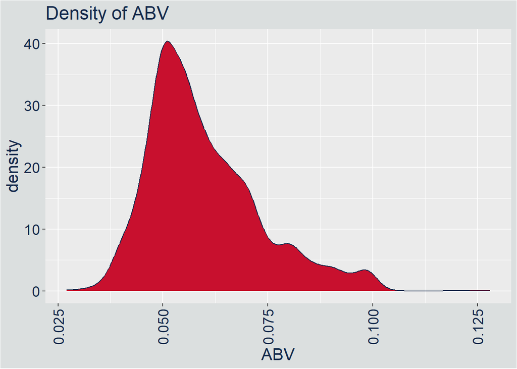

```r
#    Min. 1st Qu.  Median    Mean 3rd Qu.    Max.
# 0.02700 0.05000 0.05600 0.05973 0.06700 0.12800

# Density Plot for Overall ABV
ggplot(beers_and_breweries,aes(x = ABV)) +
  geom_density(fill = "#c8102e", color = "#13294b") +
  ggtitle("Density of ABV") +
  theme(plot.background = element_rect("#dbdfdf"),axis.text.x = element_text(angle = 90, vjust = 0.5, hjust=1, color = "#13294b",size = 14),axis.text.y = element_text(color = "#13294b",size = 14), axis.title.x = element_text(color = "#13294b",size = 16), axis.title.y =element_text(color = "#13294b",size = 16), plot.title  = element_text(color = "#13294b",size = 18))
```

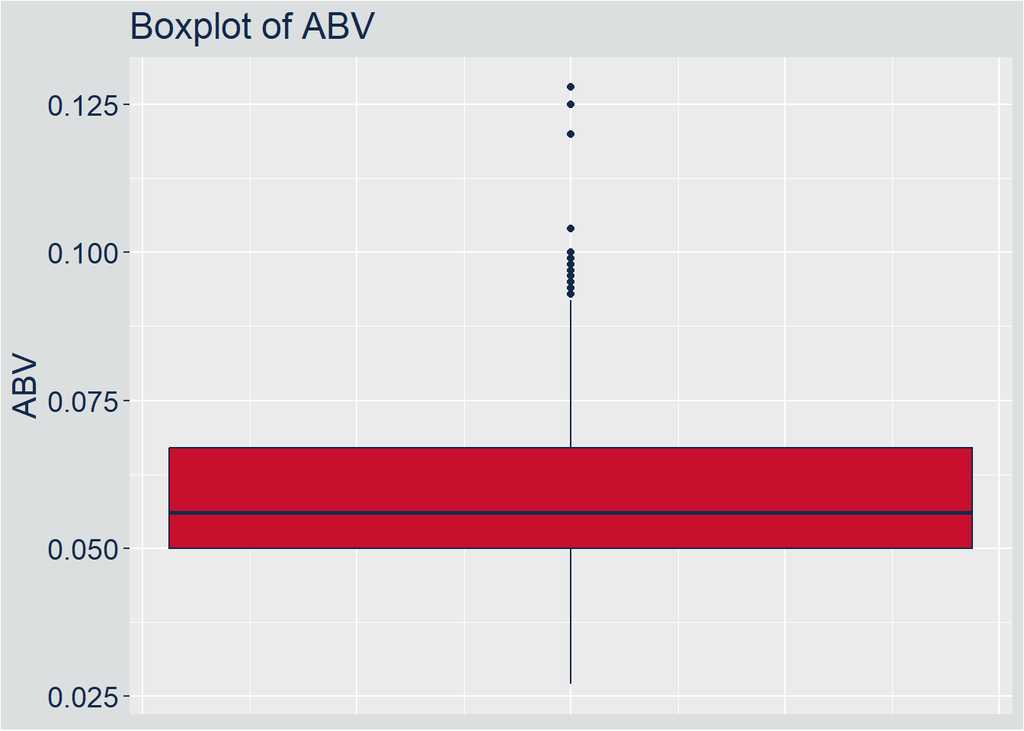

```r
# ABV Box Plot
ggplot(beers_and_breweries,aes(x = ABV)) +
  geom_boxplot(fill = "#c8102e", color = "#13294b") +
  ggtitle("Boxplot of ABV") +
  coord_flip()+
  theme(plot.background = element_rect("#dbdfdf"),
        axis.text.x = element_blank(),
        axis.text.y = element_text(color = "#13294b",size = 14),
        axis.title.x = element_text(color = "#13294b",size = 16),
        axis.title.y =element_text(color = "#13294b",size = 16),
        plot.title  = element_text(color = "#13294b",size = 18),
        axis.ticks.x = element_blank())
```

### Question 6 Answer

The minimum ABV is an American IPA with an ABV of 0.027, the median ABV is 0.056, the maximum ABV is a Quadruple with an ABV of 0.128. The mean ABV is 0.05973 and the Upper Quantile is 0.067 and the lower quantile is 0.05.

## Question 7: IBU vs ABV

We plotted a scatter plot of IBU vs ABV values

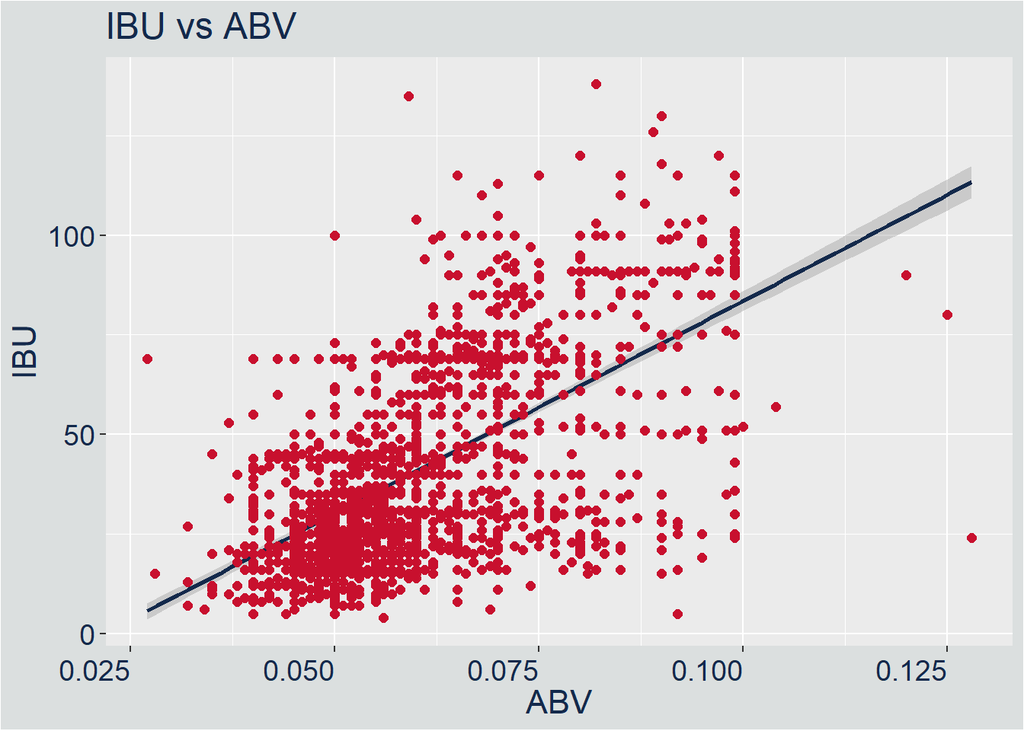

```r
## scatter plot with linear regression on data with imputed values
beers_and_breweries %>% ggplot(aes(x = ABV, y = IBU)) +
    geom_smooth(method='lm', color = "#13294b") +
  geom_point(color = "#c8102e", size = 2) +
  ggtitle("IBU vs ABV") +
  theme(plot.background = element_rect("#dbdfdf"),axis.text.x = element_text(angle = 0, vjust = 0.5, hjust=1, color = "#13294b",size = 14),axis.text.y = element_text(color = "#13294b",size = 14), axis.title.x = element_text(color = "#13294b",size = 16), axis.title.y =element_text(color = "#13294b",size = 16), plot.title  = element_text(color = "#13294b",size = 18))
```

$$IBU = -23.1 + 1.07*10^3ABV$$
$$R^2 = 0.35$$

### Question 7 Answer

We can see that with an increase in ABV values, there is an estimated increase in IBU values but we can see as ABV increases, the variability in IBU’s increases so the positive correlation between the 2 variables in not strong.

## Question 8: KNN Classification Ales vs IPA

### Organize IPA vs Ale

The beers were categorized as IPAs, Ales, or neither. We determined IPA styles and Ale styles by looking at the data. These lists of styles were then refined using ChatGPT as well as investigation of styles in the Beer Style Guide. Some styles were considered to be either, and then we let if the name of the beer had the word “Ale” in it to decide.

```r
IPA_Styles <- unique(beers_and_breweries$Style[which(grepl("IPA",beers_and_breweries$Style) |
                                                       grepl("india pale ale",beers_and_breweries$Style,ignore.case = T) |
                                                       grepl("IPA",beers_and_breweries$Beer_Name) |
                                                       grepl("india pale ale",beers_and_breweries$Beer_Name,ignore.case = T))])
beers_and_breweries[beers_and_breweries$Style == "Scottish Ale" & grepl("IPA",beers_and_breweries$Beer_Name), ] # Doesn't seem like an IPA
```

```
##             Style Brewery_id         Beer_Name Beer_ID   ABV IBU Ounces
## 1659 Scottish Ale        336 Stone's Throw IPA    1435 0.045  19     12
##               Brewery_Name  City State
## 1659 Fargo Brewing Company Fargo    ND
```

```r
beers_and_breweries[beers_and_breweries$Style == "American Black Ale" & grepl("IPA",beers_and_breweries$Beer_Name), ] # Also called Black IPA, so I'd consider an IPA
```

```
##                   Style Brewery_id                                 Beer_Name
## 920  American Black Ale        157                         Mothman Black IPA
## 1129 American Black Ale        193              Dark Voyage Black IPA (2013)
## 1918 American Black Ale        393                                 Black IPA
## 1934 American Black Ale        398                            CAPT Black IPA
## 1936 American Black Ale        398                            CAPT Black IPA
## 1989 American Black Ale        420                         Sanitas Black IPA
## 2258 American Black Ale        516                         Eclipse Black IPA
## 84   American Black Ale        131                             Black Hop IPA
## 93   American Black Ale        414 Heavy Machinery IPA Series #1: Heavy Fist
## 94   American Black Ale        207                  Next Adventure Black IPA
## 96   American Black Ale        315                         Masked Bandit IPA
##      Beer_ID   ABV IBU Ounces                      Brewery_Name       City
## 920     2313 0.067  71     12 Greenbrier Valley Brewing Company  Lewisburg
## 1129    2227 0.065  80     12                   Capital Brewery  Middleton
```

[output cut: 21 more lines]

```r
IPA_Styles <- IPA_Styles[IPA_Styles != "Scottish Ale"]
IPA_Beers <- beers_and_breweries[beers_and_breweries$Style %in% IPA_Styles,] # 627
Ale_Styles <- unique(beers_and_breweries$Style[which(grepl(" ale",beers_and_breweries$Style,ignore.case = T) |
                                                       grepl(" ale",beers_and_breweries$Beer_Name,ignore.case = T))])
Ale_Styles<- Ale_Styles[!(Ale_Styles %in% IPA_Styles)]
beers_and_breweries[beers_and_breweries$Style == "California Common / Steam Beer" & grepl("ale",beers_and_breweries$Beer_Name,ignore.case = T), ] # says it's an ale
```

```
##                               Style Brewery_id
## 6351 California Common / Steam Beer        221
##                                   Beer_Name Beer_ID   ABV IBU Ounces
## 6351 West Portal Colorado Common Summer Ale    1422 0.041  41     16
##            Brewery_Name       City State
## 6351 Big Choice Brewing Broomfield    CO
```

```r
Ale_Styles <- Ale_Styles[Ale_Styles != "California Common / Steam Beer"] # This uses lager yeast
beers_and_breweries[beers_and_breweries$Style == "American India Pale Lager" & grepl("ale",beers_and_breweries$Beer_Name,ignore.case = T), ] # Ha, has the word "pale"
```

```
##  [1] Style        Brewery_id   Beer_Name    Beer_ID      ABV
##  [6] IBU          Ounces       Brewery_Name City         State
## <0 rows> (or 0-length row.names)
```

```r
Ale_Styles <- Ale_Styles[Ale_Styles != "American India Pale Lager"] # Isn't an ale
Ale_Styles <- Ale_Styles[Ale_Styles != "American Pale Lager"] # Isn't an ale
Ale_Styles <- Ale_Styles[Ale_Styles != "Herbed / Spiced Beer"] # Can be either
Ale_Styles <- Ale_Styles[Ale_Styles != "American Amber / Red Lager"] # Can be either
Ale_Styles <- Ale_Styles[Ale_Styles != "Euro Pale Lager"] # Isn't an ale
Ale_Styles <- Ale_Styles[Ale_Styles != "Other"] # Can be either
beers_and_breweries[beers_and_breweries$Style == "Chile Beer",] # beer with chilis
```

```
##           Style Brewery_id                  Beer_Name Beer_ID   ABV IBU Ounces
## 790  Chile Beer        133 L'il Lucy's Hot Pepper Ale    2341 0.049  28     12
## 1592 Chile Beer        315               Hot Date Ale    1791 0.060  20     16
## 6361 Chile Beer        425         Patty's Chile Beer    1345 0.042  24     12
##                     Brewery_Name    City State
## 790       Weston Brewing Company  Weston    MO
## 1592 Piney River Brewing Company Bucryus    MO
## 6361     Wynkoop Brewing Company  Denver    CO
```

```r
Ale_Styles <- Ale_Styles[Ale_Styles != "Chile Beer"] # Can be either
Ale_Styles <- Ale_Styles[Ale_Styles != "Fruit / Vegetable Beer"] # Can be either
Ale_Styles <- Ale_Styles[Ale_Styles != "Baltic Porter"] # Even though porters are Ales, a Baltic Porter is a Lager, good catch by Chat GPT
unique(beers_and_breweries$Style[grepl("stout",beers_and_breweries$Style,ignore.case = T)]) # Seems stouts are missing
```

```
## [1] "Milk / Sweet Stout"               "Russian Imperial Stout"
## [3] "American Stout"                   "Foreign / Export Stout"
## [5] "Oatmeal Stout"                    "Irish Dry Stout"
## [7] "American Double / Imperial Stout" "English Stout"
```

```r
Ale_Styles <- c(Ale_Styles, "Milk / Sweet Stout", "Russian Imperial Stout", "American Stout", "Foreign / Export Stout",
                "Oatmeal Stout", "Irish Dry Stout", "American Double / Imperial Stout", "English Stout")
Ale_Styles <- c(Ale_Styles, "Dubbel", "Tripel", "Flanders Oud Bruin", "Kristalweizen",
                "Berliner Weissbier", "Bière de Garde", "Dunkelweizen", "Grisette", "Roggenbier")
Ale_Styles <- Ale_Styles[Ale_Styles != "Rye Beer"] # Can be either
Ale_Styles <- Ale_Styles[Ale_Styles != "American Pilsner"] # pilsners are lagers
Ale_Beers <- beers_and_breweries[beers_and_breweries$Style %in% Ale_Styles |
                                   (grepl(" ale",beers_and_breweries$Beer_Name,ignore.case = T) &
                                      !(beers_and_breweries$Style %in% IPA_Styles)),] # 1243
IPA_Beers$IPA_or_Ale <- "IPA"
Ale_Beers$IPA_or_Ale <- "Ale"

# Dataframe With IPA vs Ale Distinction
IPAs_and_Ales <- rbind(IPA_Beers,Ale_Beers)


# The above approach was pretty manual.
# Is it possible to pass in a list of styles to ChatGPT and have it give you list of IPAs, Ales, neither, sometimes an Ale and sometimes neither.
all_styles <- beers_and_breweries %>%
  group_by(Style) %>%
  summarize(Count=n())
all_styles
```

```
## # A tibble: 92 × 2
##    Style                      Count
##    <chr>                      <int>
##  1 Abbey Single Ale               2
##  2 Altbier                       13
##  3 American Adjunct Lager        18
##  4 American Amber / Red Ale     133
##  5 American Amber / Red Lager    29
##  6 American Barleywine            3
##  7 American Black Ale            36
##  8 American Blonde Ale          108
##  9 American Brown Ale            70
## 10 American Dark Wheat Ale        7
## # ℹ 82 more rows
```

```r
# Conversation is saved as a .txt file, it was somewhat helpful but not foolproof

# Plot the counts of IPA vs Ale vs Neither
Count <- c(607, 1285, 464)
Category <- c("IPA", "Ale", "Neither")
count_df <- data.frame(Count, Category)
count_df$Percent <- round(count_df$Count / 2356 *100,1)
count_df$Category <- factor(count_df$Category,level=c("IPA", "Ale", "Neither"))
summary(count_df)
```

```
##      Count           Category    Percent
##  Min.   : 464.0   IPA    :1   Min.   :19.70
##  1st Qu.: 535.5   Ale    :1   1st Qu.:22.75
##  Median : 607.0   Neither:1   Median :25.80
##  Mean   : 785.3               Mean   :33.33
##  3rd Qu.: 946.0               3rd Qu.:40.15
##  Max.   :1285.0               Max.   :54.50
```

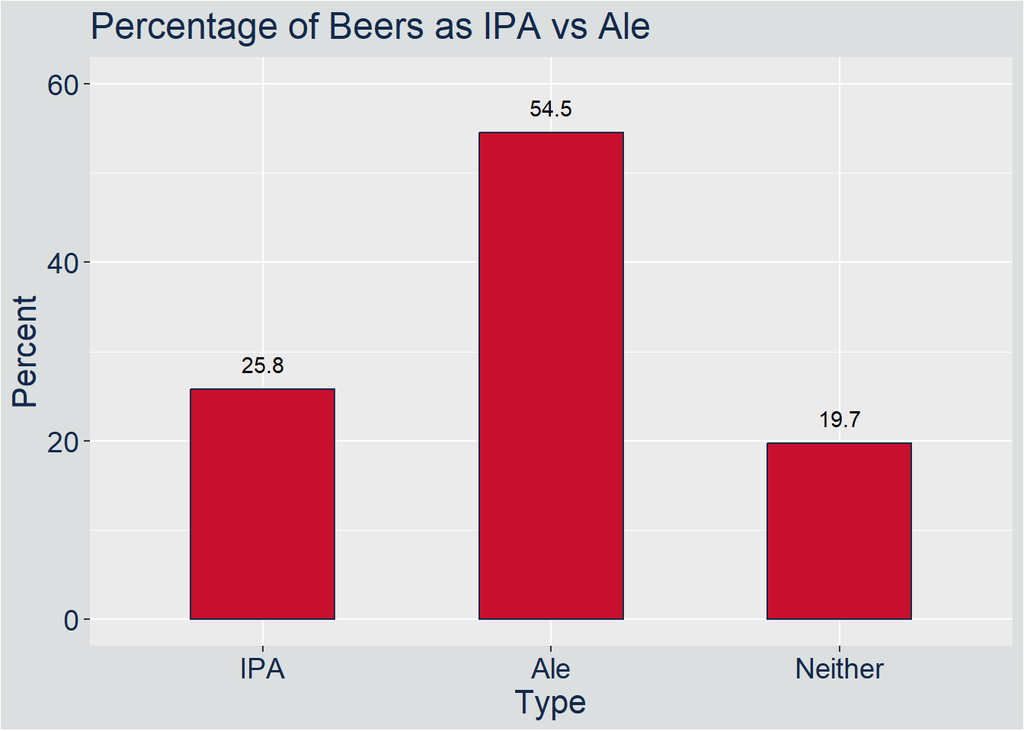

```r
ggplot(count_df,aes(x=Category, y=Percent)) +
  geom_bar(stat="identity",width=.5,position = "Dodge",fill = "#c8102e",color = "#13294b" ) +
  xlab("Type")  +
  ylab("Percent") +
  ggtitle("Percentage of Beers as IPA vs Ale")+
  geom_text(aes(label = Percent), vjust = -1) +
  ylim(0,60) +
  theme(plot.background = element_rect("#dbdfdf"),
        axis.text.x = element_text(color = "#13294b",size = 14),
        axis.text.y = element_text(color = "#13294b",size = 14),
        axis.title.x = element_text(color = "#13294b",size = 16),
        axis.title.y =element_text(color = "#13294b",size = 16),
        plot.title  = element_text(color = "#13294b",size = 18))
```

### Plots of ABV and IBU by Classification

Plot to see if there is a visual distinction between IBU and/or ABV by IPA vs Ale. There is a clear distinction for IBU, and a less clear distinction for ABV.

```r
# Check if any overlaps, there shouldn't be
merge(IPA_Beers,Ale_Beers,by="Beer_ID") # 0 rows
```

```
##  [1] Beer_ID        Style.x        Brewery_id.x   Beer_Name.x    ABV.x
##  [6] IBU.x          Ounces.x       Brewery_Name.x City.x         State.x
## [11] IPA_or_Ale.x   Style.y        Brewery_id.y   Beer_Name.y    ABV.y
## [16] IBU.y          Ounces.y       Brewery_Name.y City.y         State.y
## [21] IPA_or_Ale.y
## <0 rows> (or 0-length row.names)
```

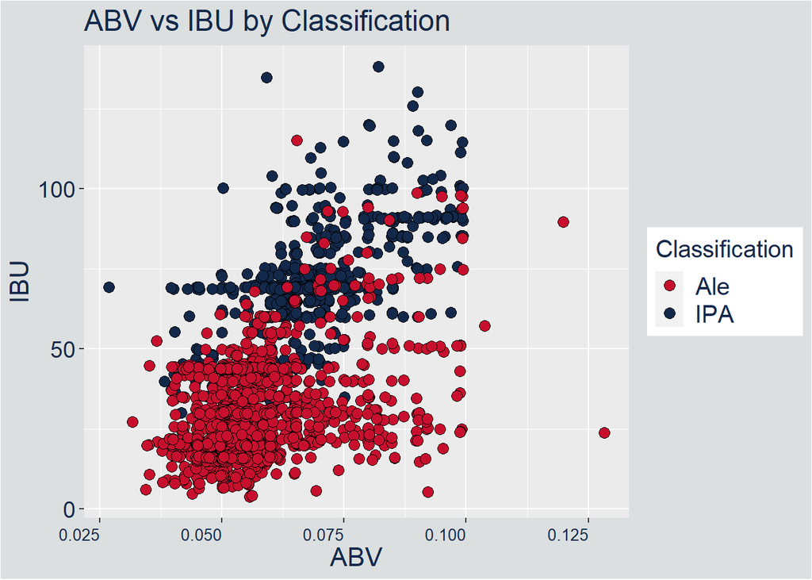

```r
colors = c("#c8102e","#13294b")

# ABV vs IBU by Classification Scatterplot
IPAs_and_Ales %>% # Looks like IPAs have higher IBUs
  ggplot(aes(x=ABV,y=IBU,fill=IPA_or_Ale)) +
  geom_point(color = "BLACK", pch = 21, size = 3, position = "jitter") +
  ggtitle('ABV vs IBU by Classification') +
  theme(plot.background = element_rect("#dbdfdf"),
        axis.text.x = element_text(angle = 0, vjust = 0.5, hjust=1, color = "#13294b",size = 10),
        axis.text.y = element_text(color = "#13294b",size = 14),
        axis.title.x = element_text(color = "#13294b",size = 16),
        axis.title.y =element_text(color = "#13294b",size = 16),
        plot.title  = element_text(color = "#13294b",size = 18),
        legend.text = element_text(color = "#13294b",size=15),
        legend.title = element_text(color = "#13294b",size=15)) +
  scale_fill_manual(values = colors, name = "Classification")
```

### KNN Predictor

We ran 100 train test splits and plotted histograms of the specificity, sensitivity, and accuracy of all of the splits.

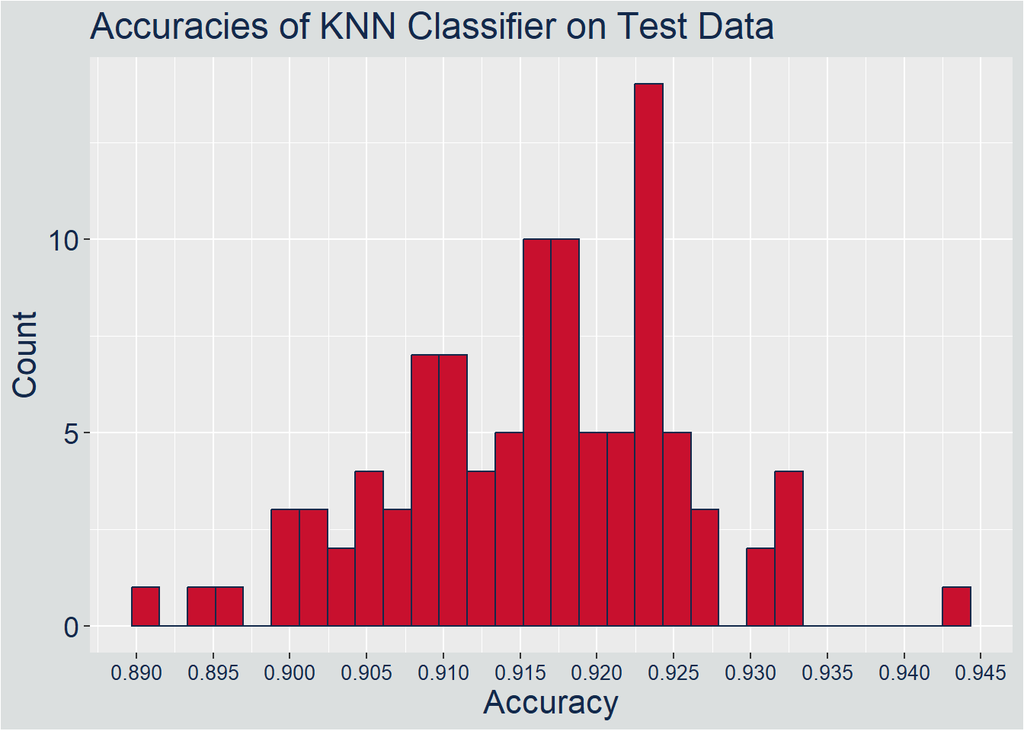

```r
# First, try with just K = 5 for 100 train and test splits 70 30 split
num_seeds <- 100
accuracies <- numeric(num_seeds)
sensitivies <- numeric(num_seeds)
specificities <- numeric(num_seeds)

for (seed in 1:100){
  set.seed(seed)
  trainIndices = sample(seq(1:length(IPAs_and_Ales$IPA_or_Ale)),round(.7*length(IPAs_and_Ales$IPA_or_Ale)))
  train = IPAs_and_Ales[trainIndices,]
  test = IPAs_and_Ales[-trainIndices,]
  classifications = knn(train[,c("ABV","IBU")],
                                test[,c("ABV","IBU")],
                                train$IPA_or_Ale, prob = TRUE, k = 5)
  CM = confusionMatrix(table(test$IPA_or_Ale,classifications))
  accuracies[seed] = CM$overall[1]
  sensitivies[seed] = CM$byClass[1]
  specificities[seed] = CM$byClass[2]
}

# Accuracy histogram for all the Test Train Splits
ggplot(data.frame(accuracies), aes(x = accuracies)) +
  geom_histogram(fill = "#c8102e", color = "#13294b") +
  xlab("Accuracy") +
  ylab("Count")+
  ggtitle("Accuracies of KNN Classifier on Test Data") +
  theme(plot.background = element_rect("#dbdfdf"),
        axis.text.x = element_text(color = "#13294b",size = 10),
        axis.text.y = element_text(color = "#13294b",size = 14),
        axis.title.x = element_text(color = "#13294b",size = 16),
        axis.title.y =element_text(color = "#13294b",size = 16),
        plot.title  = element_text(color = "#13294b",size = 18))+
  scale_x_continuous(breaks = scales::pretty_breaks(n = 20))
```

```r
min(accuracies) # 86.3%, really good minimum accuracy
```

```
## [1] 0.8908451
```

```r
max(accuracies) # 92.1%
```

```
## [1] 0.943662
```

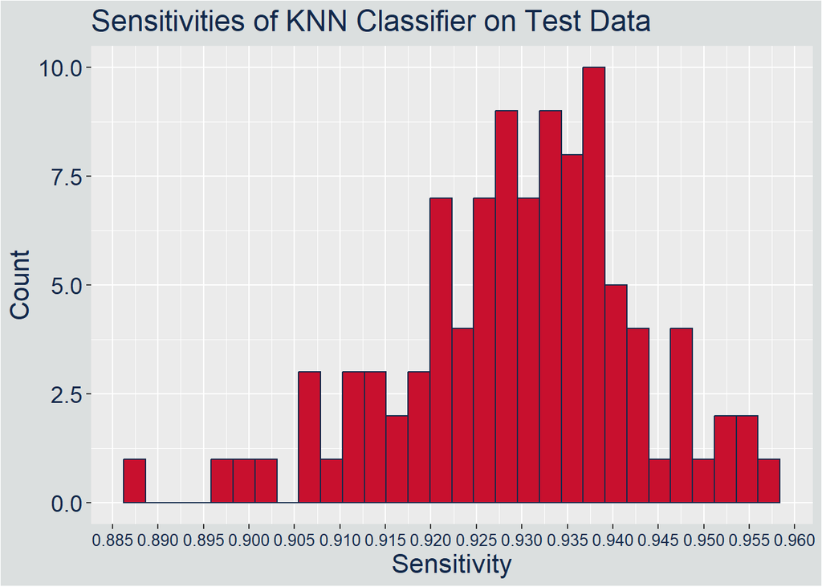

```r
# Sensitivies histogram for all the Test Train Splits
ggplot(data.frame(sensitivies), aes(x = sensitivies)) +
  geom_histogram(fill = "#c8102e", color = "#13294b") +
  xlab("Sensitivity") +
  ylab("Count")+
  ggtitle("Sensitivities of KNN Classifier on Test Data") +
  theme(plot.background = element_rect("#dbdfdf"),
        axis.text.x = element_text(color = "#13294b",size = 10),
        axis.text.y = element_text(color = "#13294b",size = 14),
        axis.title.x = element_text(color = "#13294b",size = 16),
        axis.title.y =element_text(color = "#13294b",size = 16),
        plot.title  = element_text(color = "#13294b",size = 18))+
  scale_x_continuous(breaks = scales::pretty_breaks(n = 20))
```

```r
min(sensitivies) # 89.2%, really good minimum accuracy
```

```
## [1] 0.887218
```

```r
max(sensitivies) # 95.1%
```

```
## [1] 0.956962
```

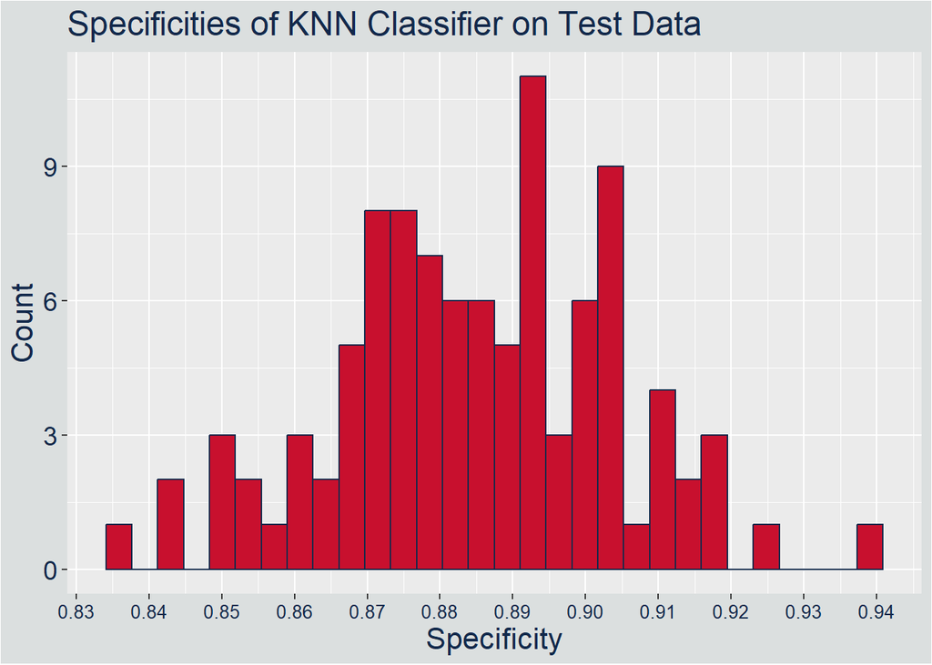

```r
# Specificities histogram for all the Test Train Splits
ggplot(data.frame(specificities), aes(x = specificities)) +
  geom_histogram(fill = "#c8102e", color = "#13294b") +
  xlab("Specificity") +
  ylab("Count")+
  ggtitle("Specificities of KNN Classifier on Test Data") +
  theme(plot.background = element_rect("#dbdfdf"),
        axis.text.x = element_text(color = "#13294b",size = 10),
        axis.text.y = element_text(color = "#13294b",size = 14),
        axis.title.x = element_text(color = "#13294b",size = 16),
        axis.title.y =element_text(color = "#13294b",size = 16),
        plot.title  = element_text(color = "#13294b",size = 18))+
  scale_x_continuous(breaks = scales::pretty_breaks(n = 15))
```

```r
min(specificities) # 79.7%, not as good, but still not bad
```

```
## [1] 0.8350515
```

```r
max(specificities) # 90.6%
```

```
## [1] 0.9382022
```

## Question 9: Other Investigation

### Densities for 5 most populare styles and states

We plotted the densities of the 5 most popular styles and states to see how they compared to the overall density.

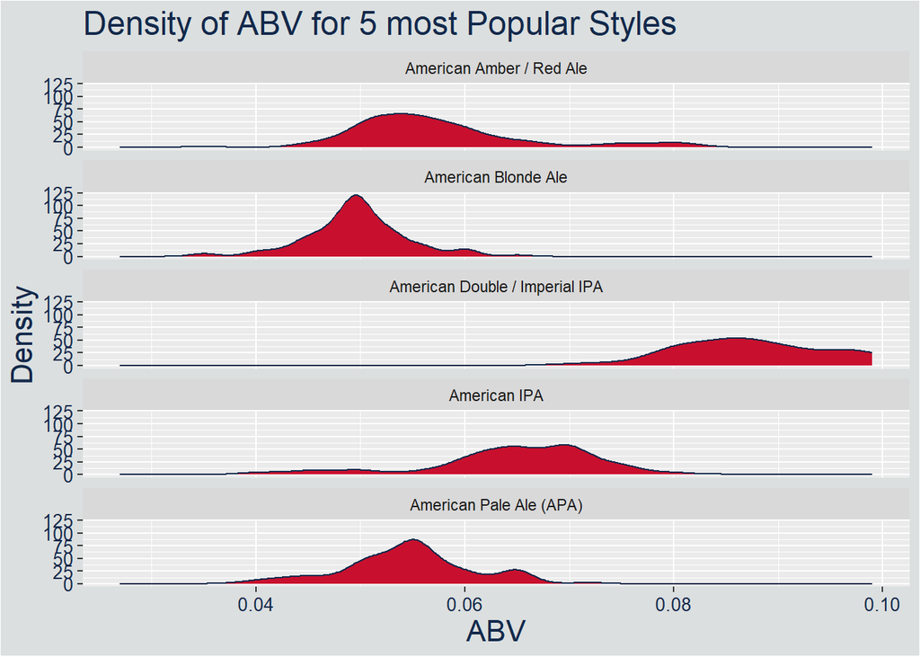

```r
# Plotting the densities for the top 5 most popular beer styles
style_counts <- beers_and_breweries %>%
  group_by(Style) %>%
  summarize(Count = n())
popular_styles <- style_counts$Style[style_counts$Count > 100]
ggplot(beers_and_breweries[beers_and_breweries$Style %in% popular_styles,],aes(x = ABV)) +
  geom_density(fill = "#c8102e", color = "#13294b") +
  ggtitle("Density of ABV for 5 most Popular Styles") +
  facet_wrap(~Style,ncol=1) +
  ylab("Density")+
  theme(plot.background = element_rect("#dbdfdf"),axis.text.x = element_text(color = "#13294b",size = 10),axis.text.y = element_text(color = "#13294b",size = 10), axis.title.x = element_text(color = "#13294b",size = 16), axis.title.y =element_text(color = "#13294b",size = 16), plot.title  = element_text(color = "#13294b",size = 18))
```

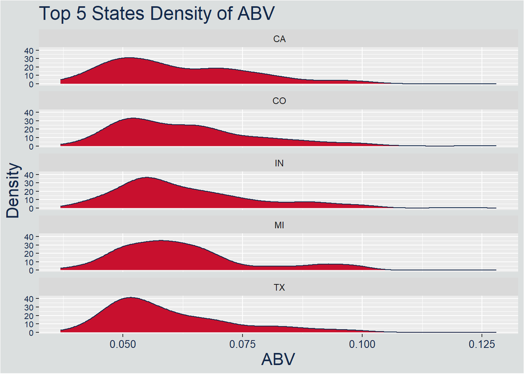

```r
# Plotting the densities for the top 5 most popular states
state_counts <- beers_and_breweries %>%
  group_by(State) %>%
  summarize(Count = n()) %>%
  arrange(desc(Count))
popular_states <- state_counts$State[state_counts$Count > 125]
ggplot(beers_and_breweries[beers_and_breweries$State %in% popular_states,],aes(x = ABV)) +
  geom_density(fill = "#c8102e", color = "#13294b") +
  ggtitle("Top 5 States Density of ABV") +
  ylab("Density")+
  facet_wrap(~State,ncol=1)  +
  theme(plot.background = element_rect("#dbdfdf"),axis.text.x = element_text(color = "#13294b",size = 10),axis.text.y = element_text(color = "#13294b",size = 8), axis.title.x = element_text(color = "#13294b",size = 16), axis.title.y =element_text(color = "#13294b",size = 16), plot.title  = element_text(color = "#13294b",size = 18))
```

### Popular styles in Colorado

We created a bar plot of the most popular beers in Colorado. Since this was the state with the most beers, we thought it would be useful for Budweiser to know the style breakdown there so that they know what types of beers to market in a location where beer is the most popular. It turned out to be similar to the country as a whole.

[figure not shown]

```r
# popular styles of beer in Colorado Bar Plot
beers_and_breweries %>%
  group_by(Style) %>%
  filter(State == " CO") %>%
  summarise(count = n()) %>%
  arrange(desc(count)) %>%
  filter(count > 10) %>%
  ggplot(aes(x = Style,y = count)) +
  geom_bar(stat = "Identity",fill = "#c8102e",color = "#13294b") +
  xlab("Style")  +
  ylab("Count") +
  ylim(0,45) +
  ggtitle("Popular Styles in Colorado")+
  geom_text(aes(label = count), vjust = -1) +
  theme(plot.background = element_rect("#dbdfdf"),
        axis.text.x = element_text(color = "#13294b",size = 12),
        axis.text.y = element_text(color = "#13294b",size = 14),
        axis.title.x = element_text(color = "#13294b",size = 16),
        axis.title.y =element_text(color = "#13294b",size = 16),
        plot.title  = element_text(color = "#13294b",size = 18))
```

### Extra Analysis

#### See if Median ABV by Style vs Median IBU by Style has a higher Correlation Coefficient

The correlation coefficient between ABV and IBU was only 0.35 for all the data. However, looking at the top 5 most popular styles, it seemed to have a much stronger correlation. We investigated if this correlation could be determined by looking at median values or by filtering on more popular styles.

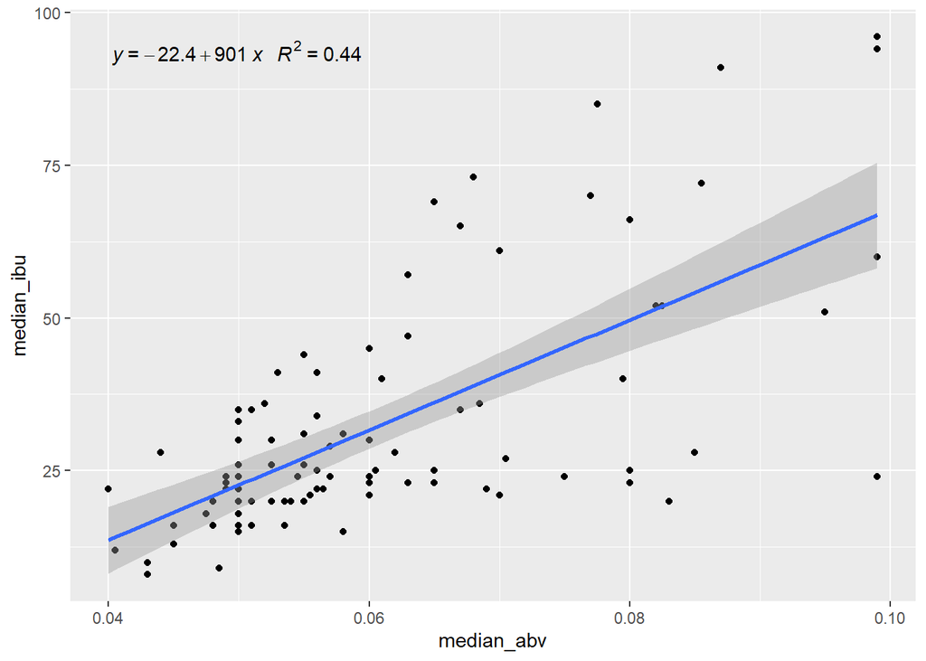

```r
# See if Median ABV by Style vs Median IBU by Style has more of a pattern
medians_by_style <- beers_and_breweries %>%
  group_by(Style) %>%
  summarise(median_abv=median(ABV),median_ibu=median(IBU),style_count=n())
medians_by_style %>% # R^2 is still only 0.44, so not much correlation here either
  ggplot(aes(x=median_abv,y=median_ibu)) +
  geom_point() +
  geom_smooth(method='lm') +
  stat_poly_eq(aes(label = paste(..eq.label.., ..rr.label.., sep = "~~~")),
               formula = y ~ x, parse = TRUE)
```

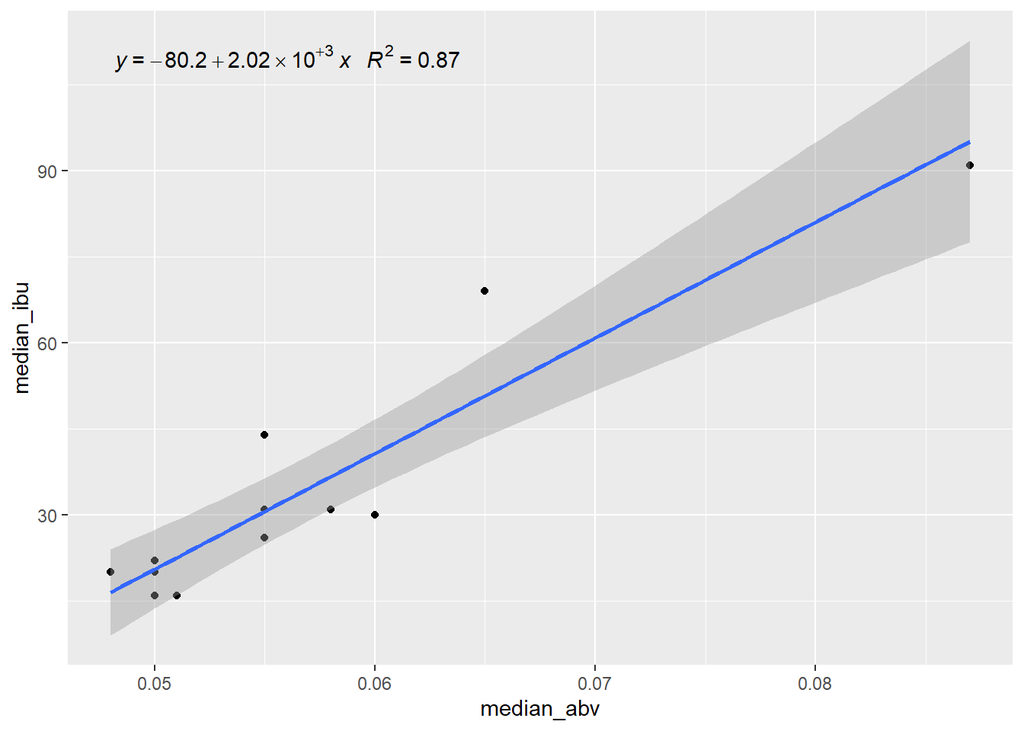

```r
medians_by_style %>% # R^2 jumps up when you remove styles without much representation
  filter(style_count>40) %>%
  ggplot(aes(x=median_abv,y=median_ibu)) +
  geom_point() +
  geom_smooth(method='lm') +
  stat_poly_eq(aes(label = paste(..eq.label.., ..rr.label.., sep = "~~~")),
               formula = y ~ x, parse = TRUE)
```

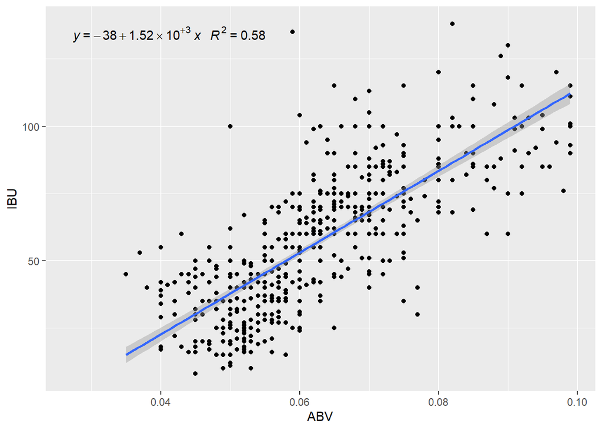

```r
# What about all the data for the most popular styles (not just the medians), is there a high correlation?
style_counts <- beers_and_breweries %>%
  group_by(Style) %>%
  summarize(Count = n())
popular_styles <- style_counts$Style[style_counts$Count > 100]
beers_and_breweries_original %>% filter(Style %in% popular_styles) %>% # R^2 is 0.58, not super high
  ggplot(aes(x=ABV,y=IBU))+
  geom_point()+
  geom_smooth(method='lm') +
  stat_poly_eq(aes(label = paste(..eq.label.., ..rr.label.., sep = "~~~")),
               formula = y ~ x, parse = TRUE)
```

It does seem that the correlation becomes higher if you remove non-popular styles (styles with a count less than 40). It jumps even higher if you only look at the median ABV vs median IBU, instead of looking at values for each individual beer.

#### Investigate the bottom right of the ABV vs IBU plot

It seems that the bottom right of the ABV vs IBU plot, ABV is high but IBU is low, is dragging down the average line and lowering the correlation coefficient. We investigated these values, and determined that there are several styles that are high ABV but low IBU. None of these styles are very popular, but several styles fall into this category.

```r
# Use plotly to look at the bottom right hand part of ABV vs IBU plot
summary(beers_and_breweries$ABV) # Median = 0.056, 3rd Quartile = 0.067
```

```
##    Min. 1st Qu.  Median    Mean 3rd Qu.    Max.
## 0.02700 0.05000 0.05600 0.05973 0.06700 0.12800
```

```r
summary(beers_and_breweries$IBU) # Median = 32, 1st Quartile = 21
```

```
##    Min. 1st Qu.  Median    Mean 3rd Qu.    Max.
##    4.00   21.00   32.00   40.52   60.00  138.00
```

```r
plot <- plot_ly(data = medians_by_style, x = ~median_abv, y = ~median_ibu,
                text = ~paste("Style: ", Style, ", Count: ",style_count),
                mode = "markers")
print(plot)
high_abv_low_ibu <- medians_by_style %>%
  filter(median_abv > 0.06 & median_ibu < 30 & style_count > 2)
sum(high_abv_low_ibu$style_count) # 89`
```

```
## [1] 89
```

```r
# CONCLUSION: There are several high profile styles that fit this category
#   Bocks, Belgian Strongs (Strong Ales in general), and Winter Ales

# Look at the .1 ABV level, since there are a lot of beers there.
# Are there common Styles and States that do this?
plot <- plot_ly(data = beers_and_breweries, x = ~ABV, y = ~IBU, text = ~paste("Beer Name: ", Beer_Name, ", Style: ",Style, ", State: ", State), mode = "markers")
print(plot)
ten_alc_beers <- beers_and_breweries %>%
  filter(ABV==0.099)
# CONCLUSION: No real common states, Total = 34
#   IPAs = 12, Stouts = 9, Barleywines = 5, Belgian Strongs = 4
```

## Conclusion

First we cleaned the data to remove non-beers and to add missing Style, ABV, and IBU values. We displayed the breweries by state and found that Colorado had the most breweries. We found each states median ABV and IBU and the maximum ABV and IBU values in the nation. We looked at various summary statistics of ABV for the nation, states with the most beer, and top styles. Then we found that there is a weak positive correlation between IBU and ABV and that these 2 variables can be used to classify beers as an Ale vs an IPA.